# Analyzing Activity Data - Course Project 1

# Analyzing Activity Data - Course Project 1

General set up for the r code chunks.

## Loading and preprocessing the data

First we will read the file (the directory was set in the console). The date column was set to be a “date” so it will be easier to work with.

```r
readActivityFile <- read.csv("activity.csv")
readActivityFile$date <- as.Date(readActivityFile$date)
```

## What is mean total number of steps taken per day?

For this part we will ignore the missing values. We will make a histogram of the number of steps each day. We will calculate the mean and median of the total steps.

```r
library(dplyr)
total_steps <-readActivityFile %>% group_by(date) %>% summarise(totalSteps = sum(steps, na.rm = TRUE))
```

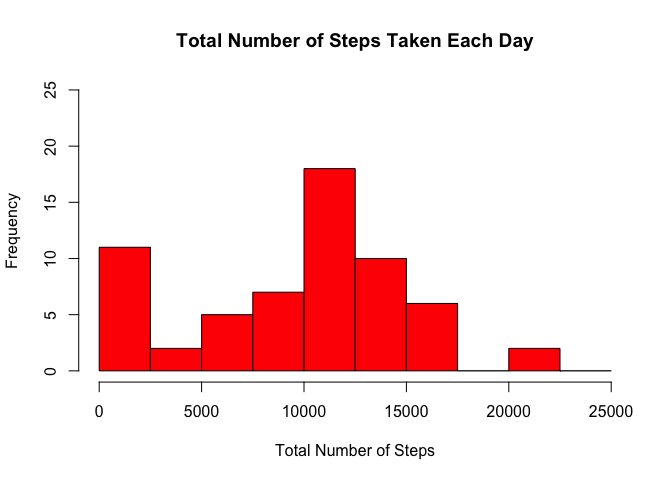

```r
total_steps$totalSteps <- as.numeric(total_steps$totalSteps)
hist(total_steps$totalSteps, xlab = "Total Number of Steps",
     main = "Total Number of Steps Taken Each Day", col = "red",  breaks=seq(from=0, to=25000, by=2500), ylim = c(0,25))
```

We will calculate the mean and median of the total steps.

```r
mean(total_steps$totalSteps)
```

```
## [1] 9354.23
```

```r
median(total_steps$totalSteps)
```

```
## [1] 10395
```

## What is the average daily activity pattern?

We will make a series plot.

```r
average_steps <-readActivityFile %>% group_by(interval) %>% summarise(average = mean(steps, na.rm = TRUE))
```

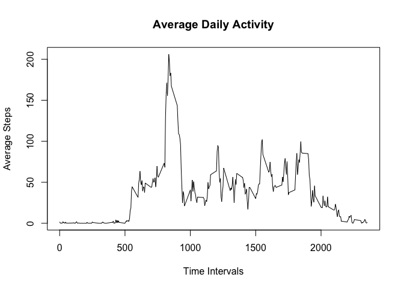

```r
plot(average_steps$interval, average_steps$average, type = "l",
     xlab = "Time Intervals", ylab = "Average Steps", main = "Average Daily Activity")
```

Which 5-minute interval, on average across all the days in the dataset, contains the maximum number of steps?

```r
subset(average_steps, average_steps$average == max(average_steps$average))
```

```
## # A tibble: 1 x 2
##   interval average
##      <int>   <dbl>
## 1      835    206.
```

## Imputing missing values

We will calculate the number of missing values.

```r
NA_values <- subset(readActivityFile, is.na(readActivityFile$steps))
nrow(NA_values)
```

```
## [1] 2304
```

Input Values for missing values by inserting the mean for than 5 minute interval. The new values will be in the new data “imputed_values”

```r
No_NA_Values <-subset(readActivityFile, !is.na(readActivityFile))
imputed_values <- readActivityFile
NA_values <- is.na(imputed_values$steps)
int_avg <- tapply(No_NA_Values$steps, No_NA_Values$interval, mean, na.rm = TRUE, simplify = T)
imputed_values$steps[NA_values] <- int_avg[as.character(imputed_values$interval[NA_values])]
```

Make histogram

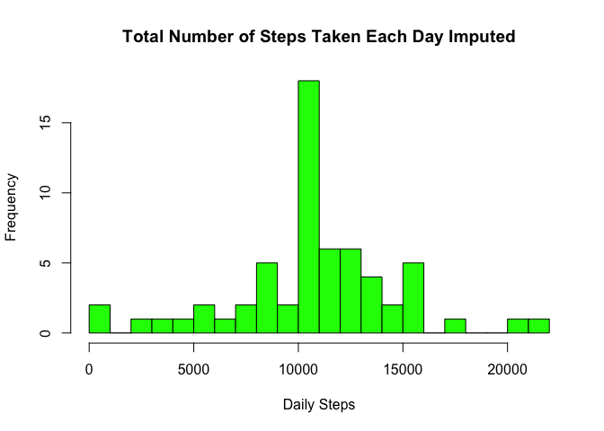

```r
new_sum <- tapply(imputed_values$steps, imputed_values$date, sum, na.rm = TRUE)

hist(new_sum, col = "green", xlab = "Daily Steps", main = "Total Number of Steps Taken Each Day Imputed", breaks = 20)
```

We will calculate the new mean and median of the total steps.

```r
mean(new_sum)
```

```
## [1] 10766.19
```

```r
median(new_sum)
```

```
## [1] 10766.19
```

We can see that the mean and the median are different from previous results, which supports the fact that the NA values do affect these values.

## Are there differences in activity patterns between weekdays and weekends?

We will use the imputed_values data. We will add to the data set a new factor, which will divide the days into weekdays and weekends. We will make 2 plots - for weekdays and weekends by subsetting by the days.

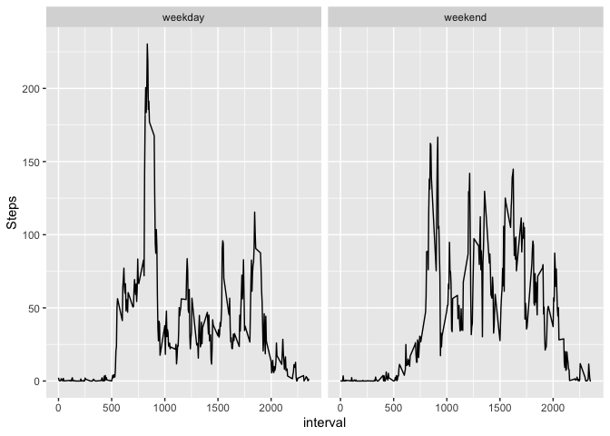

```r
library(ggplot2)
imputed_values$day_of_week <- weekdays(imputed_values$date)

imputed_values$day_type <- ifelse(imputed_values$day_of_week == "Saturday" | imputed_values$day_of_week == "Sunday", "weekend", "weekday")

#calculate mean of steps
total_steps <-imputed_values %>% group_by(interval, day_type) %>% summarise(Steps = mean(steps, na.rm = TRUE))
total_steps$Steps <- as.numeric(total_steps$Steps)

ggplot(data = total_steps, aes(interval, Steps) ) + geom_line() + facet_wrap(~total_steps$day_type)
```